# Brown recommendation adherence: implementation and reconciliation

Internal current-main record and complete sensitivity disposition

Published

September 12, 2026

## 1 Disposition and controlling record

The complete B/B80 main-model pair and bounded finishing calculations are independently verified under BA-018 / CHG-157. The scientific disposition remains qualified: Pre-sleep fails the registered 80% coverage criterion, temporal dependence remains unresolved, and failed sensitivity routes have no inferred results. Numerical completion is not unconditional scientific success or final report acceptance.

Package 011 preserves 95 supervised execution histories, including eight nonzero attempts. This report executes frozen aggregate formatting only. No fitting, prediction, simulation, resampling, contrast, confidence-interval or FDR calculation occurs here. The final BA-LB-REPORTS-REVIEW is not closed by this document.

The reader results and preparation companion use the complete main package with exact reuse of the separate exploratory extension. Writer and shared-page propagation remain separate.

## 2 Construction and exact samples

Grouping B links preceding Sleep, the full Daytime period and following three-hour Pre-sleep. The wake-start date owns Work/Free classification. Actual dates and UTC boundaries establish chronology; source-row proximity does not imply adjacent dates. Grouping C remains a stored sensitivity.

Expected duration defines coverage. Brown yes plus Brown no defines the likelihood denominator. Each window qualifies independently and exact zero/one proportions remain. No sample is rebuilt during reporting.

Table 1: Outcome, timing, coverage and valid-minute contract.

| Aspect | Construction | Interpretation |
| --- | --- | --- |
| Daytime | melEDI at least 250 lx, outside the three-hour Pre-sleep window | Near-eye primary measurement |
| Pre-sleep | melEDI at most 10 lx, in the three hours before sleep | Near-eye primary measurement |
| Sleep | melEDI at most 1 lx during recorded Sleep | Bedside measurement, not ocular or whole-bedroom exposure |
| Numerator | Number of valid minutes meeting the inclusive window-specific threshold | Threshold equality counts as adherence |
| Denominator | All valid minutes in that window, adherent plus non-adherent | Missing minutes are not imputed; exact zero and one proportions are retained |
| Coverage | Valid minutes divided by the exact expected interval duration | Expected minutes define coverage, not the model denominator |
| Independent eligibility | Any valid period is primary; at least 80% is the coverage sensitivity | One window may contribute while another is missing |
| Day ownership | Work or Free day of the wake-start calendar date | Preceding Sleep, Daytime and following Pre-sleep form one cycle; midnight does not split it |

Display source; Unrounded source 1

Table 2: Exact primary sample totals.

| Sample | Window periods | Participants | Wake-anchored cycles | Valid minutes |
| --- | --- | --- | --- | --- |
| Any valid period | 2298 | 140 | 794 | 1043192 |
| At least 80% coverage | 2069 | 140 | 762 | 996868 |

Display source; Unrounded source 1

Table 3: Complete window by site by day-type support.

| Sample | Window | Site | Day type | Periods | Participants | Both day types | Valid minutes | Expected minutes | Median valid minutes | Exactly 0% | Exactly 100% |
| --- | --- | --- | --- | --- | --- | --- | --- | --- | --- | --- | --- |
| linkage_b_any_valid | Daytime | Borås (SE) | Work day | 45 | 12 | 12 | 34883 | 36519 | 786.0 | 0 | 0 |
| linkage_b_any_valid | Pre-sleep | Borås (SE) | Work day | 45 | 12 | 12 | 7401 | 8100 | 180.0 | 1 | 2 |
| linkage_b_any_valid | Sleep | Borås (SE) | Work day | 45 | 12 | 12 | 19580 | 20267 | 420.0 | 0 | 27 |
| linkage_b_any_valid | Daytime | Delft (NL) | Work day | 41 | 12 | 12 | 29710 | 31703 | 727.0 | 1 | 0 |
| linkage_b_any_valid | Pre-sleep | Delft (NL) | Work day | 38 | 12 | 12 | 6162 | 6840 | 180.0 | 1 | 5 |
| linkage_b_any_valid | Sleep | Delft (NL) | Work day | 41 | 12 | 12 | 19908 | 20543 | 480.0 | 0 | 10 |
| linkage_b_any_valid | Daytime | Dortmund (DE) | Work day | 57 | 18 | 15 | 42555 | 45591 | 740.0 | 3 | 0 |
| linkage_b_any_valid | Pre-sleep | Dortmund (DE) | Work day | 58 | 18 | 16 | 9654 | 10440 | 180.0 | 0 | 4 |
| linkage_b_any_valid | Sleep | Dortmund (DE) | Work day | 57 | 18 | 15 | 25781 | 26895 | 465.0 | 0 | 18 |
| linkage_b_any_valid | Daytime | Tübingen (DE) | Work day | 87 | 26 | 25 | 65595 | 70079 | 754.0 | 2 | 0 |
| linkage_b_any_valid | Pre-sleep | Tübingen (DE) | Work day | 89 | 26 | 25 | 14849 | 16020 | 180.0 | 2 | 3 |
| linkage_b_any_valid | Sleep | Tübingen (DE) | Work day | 90 | 26 | 25 | 39753 | 41615 | 457.0 | 0 | 30 |
| linkage_b_any_valid | Daytime | Munich (DE) | Work day | 30 | 10 | 10 | 22002 | 23731 | 717.5 | 1 | 0 |
| linkage_b_any_valid | Pre-sleep | Munich (DE) | Work day | 30 | 10 | 10 | 5120 | 5400 | 180.0 | 0 | 1 |
| linkage_b_any_valid | Sleep | Munich (DE) | Work day | 30 | 10 | 10 | 14667 | 14898 | 480.0 | 0 | 3 |
| linkage_b_any_valid | Daytime | Madrid (ES) | Work day | 69 | 22 | 18 | 51957 | 54173 | 765.0 | 2 | 0 |
| linkage_b_any_valid | Pre-sleep | Madrid (ES) | Work day | 71 | 22 | 17 | 11719 | 12780 | 180.0 | 0 | 10 |
| linkage_b_any_valid | Sleep | Madrid (ES) | Work day | 73 | 22 | 18 | 32644 | 35655 | 470.0 | 1 | 55 |
| linkage_b_any_valid | Daytime | Izmir (TR) | Work day | 66 | 17 | 16 | 47579 | 51558 | 750.0 | 3 | 0 |
| linkage_b_any_valid | Pre-sleep | Izmir (TR) | Work day | 72 | 17 | 16 | 11371 | 12960 | 180.0 | 2 | 3 |
| linkage_b_any_valid | Sleep | Izmir (TR) | Work day | 64 | 17 | 17 | 30803 | 31020 | 482.5 | 1 | 17 |
| linkage_b_any_valid | Daytime | San José (CR) | Work day | 22 | 6 | 4 | 16686 | 17920 | 750.5 | 0 | 0 |
| linkage_b_any_valid | Pre-sleep | San José (CR) | Work day | 20 | 6 | 4 | 3364 | 3600 | 180.0 | 1 | 0 |
| linkage_b_any_valid | Sleep | San José (CR) | Work day | 23 | 6 | 4 | 9639 | 10381 | 435.0 | 1 | 6 |
| linkage_b_any_valid | Daytime | Kumasi (GH) | Work day | 41 | 14 | 13 | 31606 | 33519 | 780.0 | 0 | 0 |
| linkage_b_any_valid | Pre-sleep | Kumasi (GH) | Work day | 41 | 14 | 13 | 6291 | 7380 | 180.0 | 2 | 11 |
| linkage_b_any_valid | Sleep | Kumasi (GH) | Work day | 42 | 14 | 13 | 17598 | 19021 | 394.5 | 1 | 33 |
| linkage_b_any_valid | Daytime | Borås (SE) | Free day | 30 | 13 | 12 | 21889 | 22943 | 722.0 | 0 | 0 |
| linkage_b_any_valid | Pre-sleep | Borås (SE) | Free day | 30 | 13 | 12 | 4898 | 5400 | 180.0 | 0 | 4 |
| linkage_b_any_valid | Sleep | Borås (SE) | Free day | 30 | 13 | 12 | 14770 | 14938 | 487.5 | 0 | 13 |

[output cut: 78 more lines]

Display source; Unrounded source 1

## 3 Likelihood and repeated-measures structure

Both main samples retain F3/R3/Q2/Q1/D0: the full fixed interaction, one mean participant intercept, additive window/day-type extra-zero weights, supported-window by day-type extra-one weights and window-specific beta-binomial precision. Extra Daytime all-one mass is fixed to zero.

```r
mean_formula <- cbind(brown_yes, brown_no) ~ analysis_state * site * day_type + (1 | participant)
zero_formula <- ~ analysis_state + day_type
one_formula <- ~ boundary_one_state * day_type
dispersion_formula <- ~ analysis_state
list(mean = mean_formula, extra_zero = zero_formula,
     extra_one = one_formula, dispersion = dispersion_formula)
```

```
$mean
cbind(brown_yes, brown_no) ~ analysis_state * site * day_type +
    (1 | participant)

$extra_zero
~analysis_state + day_type

$extra_one
~boundary_one_state * day_type

$dispersion
~analysis_state
```

These formula objects describe the retained structure, not fitting calls. The implementation uses a site-unique participant key, logit mean, log precision and multinomial mixture weights. TMB calculations used Laplace integration. Structural simplification did not depend on preferred p-values. Inactive slope, cycle and endpoint-process components are not estimates of zero variance.

Table 4: Selected main and exploratory components.

| Analysis | Component | Definition | Implementation |
| --- | --- | --- | --- |
| Main analysis | Beta-binomial mean | Window * Site * Day type, plus one participant intercept | Logit mean link; Laplace likelihood |
| Main analysis | Extra all-no mass | Window + Day type | Multinomial mixture weights; no retained process-specific intercept |
| Main analysis | Extra all-yes mass | Supported window * Day type; Daytime extra all-yes mass fixed at zero | Multinomial mixture weights; no retained process-specific intercept |
| Main analysis | Dispersion | Window-specific beta-binomial precision | Log link; not an independent-minute binomial model |
| Exploratory extension | Mean adjustment | Full window/site/day-type adjustment plus within- and between-Daytime adherence and centered Free-Daytime fraction | The two association levels are fitted simultaneously |
| Exploratory extension | Participant variation | A participant intercept; no retained association-cycle intercept | Serial dependence assessed separately |

Display source; Unrounded source 1

Table 5: All saved model dispositions, including failed routes.

| Model / sensitivity | Stored disposition | Structural failure | Hard failure | Recorded reason |
| --- | --- | --- | --- | --- |
| Calendar-day chunks | acceptable with limitations | Not available | FALSE |  |
| Complementary chest | acceptable with cautions | FALSE | Not available |  |
| Ordinary-binomial diagnostic | not acceptable | Not available | TRUE |  |
| Fractional model, equal periods | acceptable | Not available | FALSE |  |
| Fractional model, minute weighting | acceptable | Not available | FALSE |  |
| Participant deletion 1 | acceptable with cautions | FALSE | Not available |  |
| Participant deletion 2 | acceptable with cautions | FALSE | Not available |  |
| Participant deletion 3 | acceptable with cautions | FALSE | Not available |  |
| Participant deletion 4 | structural failure | TRUE | Not available | hard_fit_gate |
| Participant deletion 5 | acceptable with cautions | FALSE | Not available |  |
| Omit Dortmund (DE) | acceptable with cautions | FALSE | Not available |  |
| Omit Madrid (ES) | acceptable with cautions | FALSE | Not available |  |
| Omit Izmir (TR) | acceptable with cautions | FALSE | Not available |  |
| Omit Kumasi (GH) | acceptable with cautions | FALSE | Not available |  |
| Omit Tübingen (DE) | acceptable with cautions | FALSE | Not available |  |
| Omit Borås (SE) | acceptable with cautions | FALSE | Not available |  |
| Omit Delft (NL) | acceptable with cautions | FALSE | Not available |  |
| Omit Munich (DE) | acceptable with cautions | FALSE | Not available |  |
| Omit San José (CR) | acceptable with cautions | FALSE | Not available |  |
| Primary, at least 80% coverage | acceptable with cautions | FALSE | Not available |  |
| Primary, any valid period | acceptable with cautions | FALSE | Not available |  |
| Both day types observed | acceptable with cautions | FALSE | Not available |  |
| Complete three-window cycles | acceptable with cautions | FALSE | Not available |  |
| Common dispersion | acceptable with cautions | FALSE | Not available |  |
| Exclude zero periods, endpoint route | structural failure | TRUE | Not available | endpoint_separation |
| Exclude zero periods, conditional route | acceptable with cautions | FALSE | Not available |  |
| Strict rather than inclusive thresholds | acceptable with cautions | FALSE | Not available |  |
| At least 70% coverage | acceptable with cautions | FALSE | Not available |  |
| At least 90% coverage | acceptable with cautions | FALSE | Not available |  |
| More than 30 valid minutes | acceptable with cautions | FALSE | Not available |  |
| More than 5 valid minutes | acceptable with cautions | FALSE | Not available |  |
| Any-valid temporal endpoint model | structural failure | TRUE | Not available | convergence;gradient;hessian;covariance;endpoint_uncertainty |
| Any-valid temporal beta-binomial fallback | acceptable with limitations | FALSE | Not available |  |
| 80% temporal endpoint model | structural failure | TRUE | Not available | convergence;gradient;hessian;covariance;endpoint_uncertainty |
| 80% temporal beta-binomial fallback | acceptable with limitations | FALSE | Not available |  |

Every recorded route remains visible. Ineligible or failed routes have no derived inference. Near-boundary cautions do not imply absence of variation.

Display source; Unrounded source 1

## 4 Means, contrasts and multiplicity

Every main value comes from the complete current joint model, including windows with unchanged underlying observations. Population-average adherence integrates the participant distribution; nine sites each receive equal weight. The reference is not a pooled-minute fraction.

The first five main BH families are retained separately within each sample. The sixth main family is one primary 27-test adjustment with an identical unadjusted coverage repetition. The exploratory four-member family is separate. CI exclusion and FDR thresholds are not interchangeable.

Table 6: All equal-site adherence levels and 95% CIs.

| Sample | Window | Day type | Recommendation adherence (95% CI) |
| --- | --- | --- | --- |
| Any valid period | Daytime | Work day | 26.6% (24.5% to 28.7%) |
| Any valid period | Daytime | Free day | 21.5% (19.2% to 23.8%) |
| Any valid period | Pre-sleep | Work day | 62.0% (58.8% to 65.2%) |
| Any valid period | Pre-sleep | Free day | 67.9% (64.2% to 71.6%) |
| Any valid period | Sleep | Work day | 90.4% (88.9% to 91.9%) |
| Any valid period | Sleep | Free day | 83.9% (81.4% to 86.5%) |
| At least 80% coverage | Daytime | Work day | 26.9% (24.8% to 29.1%) |
| At least 80% coverage | Daytime | Free day | 21.3% (18.9% to 23.6%) |
| At least 80% coverage | Pre-sleep | Work day | 62.7% (59.4% to 66.0%) |
| At least 80% coverage | Pre-sleep | Free day | 66.8% (62.7% to 70.9%) |
| At least 80% coverage | Sleep | Work day | 90.1% (88.5% to 91.6%) |
| At least 80% coverage | Sleep | Free day | 83.8% (81.3% to 86.3%) |

Display source; Unrounded source 1

Table 7: Window-specific Free-minus-Work differences.

| Sample | Window | Free minus Work (95% CI) | Raw p | FDR-adjusted p |
| --- | --- | --- | --- | --- |
| Any valid period | Daytime | -5.1 pp (-7.8 pp to -2.4 pp) | <0.001 | <0.001 |
| Any valid period | Pre-sleep | +5.9 pp (+1.4 pp to +10.5 pp) | 0.011 | 0.011 |
| Any valid period | Sleep | -6.5 pp (-9.1 pp to -3.8 pp) | <0.001 | <0.001 |
| At least 80% coverage | Daytime | -5.7 pp (-8.5 pp to -2.9 pp) | <0.001 | <0.001 |
| At least 80% coverage | Pre-sleep | +4.1 pp (-0.9 pp to +9.1 pp) | 0.105 | 0.105 |
| At least 80% coverage | Sleep | -6.3 pp (-9.0 pp to -3.6 pp) | <0.001 | <0.001 |

Differences are percentage points. One three-window FDR family is retained within each sample. Confidence intervals and FDR decisions are separate summaries.

Display source; Unrounded source 1

Table 8: Window-specific and global site interaction tests.

| Sample | Comparison | Wald statistic | df | Raw p | FDR-adjusted p |
| --- | --- | --- | --- | --- | --- |
| Any valid period | Window by site by day type | 32.67 | 16 | 0.008 | 0.008 |
| At least 80% coverage | Window by site by day type | 30.71 | 16 | 0.015 | 0.015 |
| Any valid period | Daytime site by day type | 26.14 | 8 | <0.001 | 0.002 |
| Any valid period | Pre-sleep site by day type | 4.41 | 8 | 0.818 | 0.818 |
| Any valid period | Sleep site by day type | 24.93 | 8 | 0.002 | 0.002 |
| At least 80% coverage | Daytime site by day type | 22.87 | 8 | 0.004 | 0.005 |
| At least 80% coverage | Pre-sleep site by day type | 4.58 | 8 | 0.801 | 0.801 |
| At least 80% coverage | Sleep site by day type | 25.99 | 8 | 0.001 | 0.003 |

Display source; Unrounded source 1; Unrounded source 2

Table 9: Primary compact site and day-type table.

| Location | Work day Daytime | Work day Pre-sleep | Work day Sleep | Free day Daytime | Free day Pre-sleep | Free day Sleep |
| --- | --- | --- | --- | --- | --- | --- |
| Equal-site average | 26.6% (24.5% to 28.7%) | 62.0% (58.8% to 65.2%) | 90.4% (88.9% to 91.9%) | **-5.1 pp** (-7.8 pp to -2.4 pp) **p = <0.001** **21.5%** (19.2% to 23.8%) | **+5.9 pp** (+1.4 pp to +10.5 pp) **p = 0.011** **67.9%** (64.2% to 71.6%) | **-6.5 pp** (-9.1 pp to -3.8 pp) **p = <0.001** **83.9%** (81.4% to 86.5%) |
| Borås (SE) | **+8.6 pp** (+2.3 pp to +15.0 pp) **p = 0.032** **35.2%** (28.4% to 42.0%) | +6.9 pp (-1.1 pp to +14.9 pp) p = 0.208 68.9% (60.6% to 77.1%) | **+5.7 pp** (+3.8 pp to +7.7 pp) **p = <0.001** **96.2%** (94.4% to 97.9%) | +8.6 pp (+1.7 pp to +15.4 pp) p = 0.053 30.0% (22.7% to 37.4%) | +0.4 pp (-9.0 pp to +9.9 pp) p = 0.997 68.3% (58.3% to 78.3%) | +2.6 pp (-6.5 pp to +11.6 pp) p = 0.746 86.5% (77.0% to 96.0%) |
| Delft (NL) | +3.9 pp (-2.4 pp to +10.3 pp) p = 0.395 30.5% (23.6% to 37.4%) | +2.9 pp (-7.6 pp to +13.3 pp) p = 0.746 64.8% (53.5% to 76.1%) | +0.0 pp (-3.4 pp to +3.4 pp) p = 0.997 90.4% (86.8% to 94.1%) | +6.9 pp (-0.9 pp to +14.7 pp) p = 0.197 28.4% (19.9% to 36.9%) | +5.0 pp (-5.5 pp to +15.4 pp) p = 0.590 72.9% (61.8% to 84.0%) | -2.4 pp (-8.7 pp to +4.0 pp) p = 0.631 81.6% (74.8% to 88.4%) |
| Dortmund (DE) | +2.2 pp (-3.3 pp to +7.7 pp) p = 0.631 28.8% (23.0% to 34.6%) | -3.5 pp (-11.4 pp to +4.3 pp) p = 0.601 58.5% (50.4% to 66.6%) | +0.1 pp (-3.1 pp to +3.2 pp) p = 0.997 90.5% (87.1% to 93.8%) | **+17.0 pp** (+9.8 pp to +24.2 pp) **p = <0.001** **38.5%** (30.7% to 46.3%) | -1.0 pp (-10.6 pp to +8.5 pp) p = 0.940 66.9% (56.8% to 77.0%) | +2.5 pp (-3.1 pp to +8.1 pp) p = 0.601 86.4% (80.6% to 92.2%) |
| Tübingen (DE) | -2.6 pp (-6.8 pp to +1.6 pp) p = 0.395 24.0% (19.8% to 28.2%) | -0.6 pp (-7.3 pp to +6.1 pp) p = 0.948 61.4% (54.8% to 68.0%) | +0.6 pp (-2.0 pp to +3.1 pp) p = 0.803 91.0% (88.4% to 93.6%) | -4.4 pp (-8.5 pp to -0.3 pp) p = 0.094 17.1% (13.2% to 21.0%) | -5.8 pp (-13.3 pp to +1.7 pp) p = 0.262 62.1% (54.6% to 69.6%) | +0.0 pp (-4.4 pp to +4.4 pp) p = 0.997 83.9% (79.6% to 88.3%) |
| Munich (DE) | +4.6 pp (-2.7 pp to +11.9 pp) p = 0.395 31.2% (23.3% to 39.1%) | -3.8 pp (-14.0 pp to +6.4 pp) p = 0.631 58.1% (47.2% to 69.1%) | **-13.8 pp** (-20.7 pp to -7.0 pp) **p = <0.001** **76.6%** (69.0% to 84.2%) | -2.2 pp (-8.0 pp to +3.6 pp) p = 0.631 19.2% (13.2% to 25.3%) | -8.4 pp (-20.0 pp to +3.3 pp) p = 0.305 59.5% (46.9% to 72.1%) | **-17.2 pp** (-26.1 pp to -8.3 pp) **p = <0.001** **66.7%** (57.0% to 76.5%) |
| Madrid (ES) | +4.0 pp (-1.1 pp to +9.0 pp) p = 0.262 30.5% (25.2% to 35.8%) | -1.0 pp (-9.3 pp to +7.3 pp) p = 0.931 61.0% (52.3% to 69.6%) | **+7.1 pp** (+5.6 pp to +8.7 pp) **p = <0.001** **97.6%** (96.5% to 98.6%) | -5.2 pp (-10.1 pp to -0.4 pp) p = 0.094 16.3% (11.4% to 21.1%) | +0.2 pp (-8.7 pp to +9.1 pp) p = 0.997 68.1% (58.9% to 77.3%) | **+10.5 pp** (+7.3 pp to +13.8 pp) **p = <0.001** **94.5%** (91.9% to 97.0%) |
| Izmir (TR) | **-7.4 pp** (-11.7 pp to -3.0 pp) **p = 0.004** **19.2%** (14.8% to 23.6%) | -6.6 pp (-14.2 pp to +0.9 pp) p = 0.197 55.3% (47.7% to 63.0%) | **-6.1 pp** (-10.6 pp to -1.5 pp) **p = 0.033** **84.3%** (79.4% to 89.3%) | -4.4 pp (-9.7 pp to +1.0 pp) p = 0.236 17.1% (11.7% to 22.6%) | -10.6 pp (-21.0 pp to -0.3 pp) p = 0.114 57.3% (46.3% to 68.3%) | **-8.4 pp** (-14.6 pp to -2.3 pp) **p = 0.032** **75.5%** (68.9% to 82.1%) |
| San José (CR) | -7.7 pp (-14.3 pp to -1.2 pp) p = 0.068 18.8% (11.8% to 25.9%) | -5.0 pp (-17.8 pp to +7.7 pp) p = 0.631 57.0% (43.1% to 70.8%) | -1.1 pp (-6.1 pp to +3.8 pp) p = 0.803 89.3% (83.8% to 94.8%) | -4.4 pp (-14.0 pp to +5.1 pp) p = 0.598 17.1% (6.5% to 27.6%) | +4.7 pp (-10.3 pp to +19.7 pp) p = 0.706 72.6% (56.1% to 89.2%) | -1.4 pp (-12.3 pp to +9.4 pp) p = 0.931 82.5% (70.4% to 94.6%) |
| Kumasi (GH) | -5.6 pp (-10.8 pp to -0.4 pp) p = 0.094 21.0% (15.5% to 26.4%) | +10.9 pp (+0.9 pp to +20.9 pp) p = 0.094 72.9% (62.2% to 83.6%) | **+7.6 pp** (+6.0 pp to +9.1 pp) **p = <0.001** **98.0%** (96.8% to 99.1%) | **-11.8 pp** (-15.8 pp to -7.8 pp) **p = <0.001** **9.7%** (6.0% to 13.4%) | **+15.5 pp** (+9.0 pp to +22.0 pp) **p = <0.001** **83.4%** (77.2% to 89.6%) | **+13.9 pp** (+11.3 pp to +16.4 pp) **p = <0.001** **97.8%** (96.5% to 99.1%) |

Each cell shows an estimate and 95% CI. The average Free-day row compares with the average Work day. Each site cell compares with the equal-site average on that same day type, followed by its adherence level. All p-values are stored FDR-adjusted values. Bold estimates and p-values meet the corresponding threshold; CIs are not bold. Site comparisons are from one pooled model, not independent replications.

Display source; Unrounded source 1

Table 10: Testing families and coverage roles.

| Question | Primary tests | Primary adjustment | Coverage-sensitivity role |
| --- | --- | --- | --- |
| Equal-site Free-minus-Work differences | 3 | Benjamini-Hochberg within this family | Complete family repeated with a separate adjustment within the 80% sample |
| Window-specific site heterogeneity | 3 | Benjamini-Hochberg within this family | Complete family repeated with a separate adjustment within the 80% sample |
| Global window by site by day-type interaction | 1 | Benjamini-Hochberg within this family | Complete family repeated with a separate adjustment within the 80% sample |
| Site-specific Free-minus-Work differences from zero | 27 | Benjamini-Hochberg within this family | Complete family repeated with a separate adjustment within the 80% sample |
| Site minus equal-site adherence on each day type | 54 | Benjamini-Hochberg within this family | Complete family repeated with a separate adjustment within the 80% sample |
| Site Free-minus-Work effect minus equal-site effect | 27 | Benjamini-Hochberg within this family | Identical 27 contrasts, without a second FDR family; estimability, direction and interval checks |
| Within- and between-participant cross-state associations | 4 | Benjamini-Hochberg within this family | Identical four-effect stability check; no merging with a main-analysis family |

Confidence-interval exclusion and FDR-threshold decisions are distinct. Each family addresses a different question; adjusted values are read from stored outputs.

Display source; Unrounded source 1; Unrounded source 2; Unrounded source 3; Unrounded source 4; Unrounded source 5; Unrounded source 6; Unrounded source 7

Table 11: All site-effect-minus-average comparisons and coverage checks.

| Window | Site | Site effect minus equal-site effect (95% CI) | Primary FDR-adjusted p | At least 80% (95% CI) | Direction retained | CI conclusion retained |
| --- | --- | --- | --- | --- | --- | --- |
| Daytime | Borås (SE) | -0.1 pp (-8.1 pp to +8.0 pp) | 0.986 | -0.0 pp (-8.4 pp to +8.3 pp) | Yes | Yes |
| Daytime | Delft (NL) | +3.0 pp (-5.8 pp to +11.8 pp) | 0.691 | +3.0 pp (-6.4 pp to +12.3 pp) | Yes | Yes |
| Daytime | Dortmund (DE) | +14.8 pp (+6.7 pp to +22.9 pp) | 0.004 | +14.4 pp (+6.0 pp to +22.7 pp) | Yes | Yes |
| Daytime | Tübingen (DE) | -1.8 pp (-7.0 pp to +3.3 pp) | 0.691 | -1.7 pp (-7.1 pp to +3.7 pp) | Yes | Yes |
| Daytime | Munich (DE) | -6.9 pp (-15.0 pp to +1.3 pp) | 0.444 | -6.0 pp (-14.6 pp to +2.6 pp) | Yes | Yes |
| Daytime | Madrid (ES) | -9.2 pp (-15.6 pp to -2.8 pp) | 0.044 | -9.2 pp (-15.6 pp to -2.7 pp) | Yes | Yes |
| Daytime | Izmir (TR) | +3.0 pp (-3.1 pp to +9.2 pp) | 0.691 | +2.0 pp (-4.5 pp to +8.4 pp) | Yes | Yes |
| Daytime | San José (CR) | +3.3 pp (-7.2 pp to +13.9 pp) | 0.691 | +3.7 pp (-7.0 pp to +14.4 pp) | Yes | Yes |
| Daytime | Kumasi (GH) | -6.2 pp (-12.2 pp to -0.2 pp) | 0.285 | -6.1 pp (-12.3 pp to +0.1 pp) | Yes | No |
| Pre-sleep | Borås (SE) | -6.5 pp (-17.9 pp to +5.0 pp) | 0.691 | -9.2 pp (-21.5 pp to +3.1 pp) | Yes | Yes |
| Pre-sleep | Delft (NL) | +2.1 pp (-11.8 pp to +16.0 pp) | 0.896 | -5.0 pp (-21.7 pp to +11.8 pp) | No | Yes |
| Pre-sleep | Dortmund (DE) | +2.5 pp (-9.1 pp to +14.1 pp) | 0.824 | +3.2 pp (-9.5 pp to +15.9 pp) | Yes | Yes |
| Pre-sleep | Tübingen (DE) | -5.2 pp (-14.5 pp to +4.1 pp) | 0.691 | -1.2 pp (-11.2 pp to +8.7 pp) | Yes | Yes |
| Pre-sleep | Munich (DE) | -4.5 pp (-19.0 pp to +9.9 pp) | 0.691 | -5.8 pp (-21.0 pp to +9.3 pp) | Yes | Yes |
| Pre-sleep | Madrid (ES) | +1.2 pp (-9.8 pp to +12.3 pp) | 0.896 | +4.9 pp (-6.8 pp to +16.5 pp) | Yes | Yes |
| Pre-sleep | Izmir (TR) | -4.0 pp (-15.9 pp to +8.0 pp) | 0.691 | +4.0 pp (-9.6 pp to +17.6 pp) | No | Yes |
| Pre-sleep | San José (CR) | +9.7 pp (-8.5 pp to +28.0 pp) | 0.691 | +7.5 pp (-11.7 pp to +26.7 pp) | Yes | Yes |
| Pre-sleep | Kumasi (GH) | +4.6 pp (-6.9 pp to +16.1 pp) | 0.691 | +1.7 pp (-10.6 pp to +14.0 pp) | Yes | Yes |
| Sleep | Borås (SE) | -3.2 pp (-12.3 pp to +5.9 pp) | 0.691 | -4.1 pp (-13.5 pp to +5.4 pp) | Yes | Yes |
| Sleep | Delft (NL) | -2.4 pp (-9.1 pp to +4.4 pp) | 0.691 | -2.9 pp (-9.6 pp to +3.7 pp) | Yes | Yes |
| Sleep | Dortmund (DE) | +2.4 pp (-3.7 pp to +8.5 pp) | 0.691 | +3.0 pp (-3.2 pp to +9.2 pp) | Yes | Yes |
| Sleep | Tübingen (DE) | -0.5 pp (-5.3 pp to +4.2 pp) | 0.896 | -0.2 pp (-4.9 pp to +4.6 pp) | Yes | Yes |
| Sleep | Munich (DE) | -3.4 pp (-13.5 pp to +6.8 pp) | 0.691 | -2.1 pp (-12.2 pp to +8.1 pp) | Yes | Yes |
| Sleep | Madrid (ES) | +3.4 pp (-0.0 pp to +6.8 pp) | 0.285 | +3.1 pp (-0.3 pp to +6.6 pp) | Yes | Yes |
| Sleep | Izmir (TR) | -2.3 pp (-9.5 pp to +4.8 pp) | 0.691 | -3.4 pp (-10.7 pp to +3.9 pp) | Yes | Yes |
| Sleep | San José (CR) | -0.3 pp (-11.7 pp to +11.0 pp) | 0.986 | +0.1 pp (-11.3 pp to +11.4 pp) | No | Yes |
| Sleep | Kumasi (GH) | +6.3 pp (+3.5 pp to +9.1 pp) | <0.001 | +6.4 pp (+3.5 pp to +9.3 pp) | Yes | Yes |

All 27 comparisons are shown. The indexed site is included with weight 1/9 in its window-specific equal-site reference. Only the primary 27 tests form this FDR family; the coverage repetition has no additional FDR adjustment.

Display source; Unrounded source 1

## 5 Calibration and coverage

Main endpoint calibration passes all five applicable predictive envelopes in both samples. Overall adherence remains acceptable with limitations, and actual-date temporal triggers remain present. These are separate assessments.

The primary Pre-sleep CI excludes zero, but its at-least-80% CI includes zero. Direction is retained; the registered coverage gate is false. This is neither evidence of no association nor a test comparing the two estimates.

Table 12: Observed endpoint counts and stored predictive envelopes.

| Sample | Window | Endpoint | Observed periods | Predicted median | 95% predictive envelope | In envelope | Applicable to endpoint check |
| --- | --- | --- | --- | --- | --- | --- | --- |
| Any valid period | Sleep | all-no period | 7 | 6.0 | 2.0 to 12.0 | Yes | Yes |
| Any valid period | Sleep | all-yes period | 308 | 302.0 | 280.0 to 326.0 | Yes | Yes |
| Any valid period | Daytime | all-no period | 28 | 27.0 | 18.0 to 37.0 | Yes | Yes |
| Any valid period | Daytime | all-yes period | 1 | 0.0 | 0.0 to 0.0 | No | No |
| Any valid period | Pre-sleep | all-no period | 16 | 11.0 | 5.0 to 18.0 | Yes | Yes |
| Any valid period | Pre-sleep | all-yes period | 88 | 80.0 | 65.0 to 96.0 | Yes | Yes |
| At least 80% coverage | Sleep | all-no period | 6 | 6.0 | 1.2 to 10.8 | Yes | Yes |
| At least 80% coverage | Sleep | all-yes period | 282 | 278.0 | 256.2 to 300.8 | Yes | Yes |
| At least 80% coverage | Daytime | all-no period | 25 | 25.0 | 16.2 to 34.8 | Yes | Yes |
| At least 80% coverage | Daytime | all-yes period | 1 | 0.0 | 0.0 to 0.0 | No | No |
| At least 80% coverage | Pre-sleep | all-no period | 9 | 8.0 | 3.0 to 14.0 | Yes | Yes |
| At least 80% coverage | Pre-sleep | all-yes period | 60 | 55.0 | 40.0 to 70.5 | Yes | Yes |

These are previously calculated conditional predictive envelopes, not confidence intervals for an adherence mean. Daytime extra all-yes mass was fixed at zero; its observed all-yes row is descriptive.

Display source; Unrounded source 1; Unrounded source 2

Table 13: Exact any-valid versus at-least-80% claim gate.

| Window | Any valid period | At least 80% | Absolute shift (pp) | Direction retained | CI conclusion retained | Coverage criterion met |
| --- | --- | --- | --- | --- | --- | --- |
| Pre-sleep | +5.9 pp (+1.4 pp to +10.5 pp) | +4.1 pp (-0.9 pp to +9.1 pp) | 1.80 | Yes | No | No |
| Sleep | -6.5 pp (-9.1 pp to -3.8 pp) | -6.3 pp (-9.0 pp to -3.6 pp) | 0.22 | Yes | Yes | Yes |
| Daytime | -5.1 pp (-7.8 pp to -2.4 pp) | -5.7 pp (-8.5 pp to -2.9 pp) | 0.59 | Yes | Yes | Yes |

Display source; Unrounded source 1

Table 14: Main, chest and temporal diagnostic dispositions.

| Sample | Check | Assessment | Detail |
| --- | --- | --- | --- |
| Any valid period | overall adherence | acceptable with limitations | maximum absolute state-site-day-type adherence calibration difference 0.055 |
| Any valid period | endpoint probabilities | acceptable | 5 of 5 applicable state endpoint envelopes passed |
| Any valid period | actual date temporal dependence | triggered | 3 state residual series reached the temporal trigger |
| Any valid period | frozen primary numerical fit | acceptable with cautions | Stored numerical status; primary model was not refitted |
| At least 80% coverage | overall adherence | acceptable with limitations | maximum absolute state-site-day-type adherence calibration difference 0.088 |
| At least 80% coverage | endpoint probabilities | acceptable | 5 of 5 applicable state endpoint envelopes passed |
| At least 80% coverage | actual date temporal dependence | triggered | 3 state residual series reached the temporal trigger |
| At least 80% coverage | frozen primary numerical fit | acceptable with cautions | Stored numerical status; primary model was not refitted |
| Complementary chest | overall adherence | acceptable with limitations | maximum absolute state-site-day-type adherence calibration difference 0.074 |
| Complementary chest | endpoint probabilities | acceptable | 3 of 3 applicable state endpoint envelopes passed |
| Complementary chest | actual date temporal dependence | triggered | 1 state residual series reached the temporal trigger |
| Complementary chest | frozen numerical fit | acceptable with cautions | Separate two-window eight-site chest sensitivity; not a placement comparison test |
| Any-valid temporal fallback | overall adherence | acceptable with limitations | maximum absolute state-site-day-type adherence calibration difference 0.057 |
| Any-valid temporal fallback | endpoint probabilities | not acceptable | 0 of 5 applicable state endpoint envelopes passed |
| Any-valid temporal fallback | actual date temporal dependence | triggered | 1 state residual series reached the temporal trigger |
| Any-valid temporal fallback | temporal numerical fit | acceptable with limitations | Selected sensitivity route BB-R0 ; not a primary replacement |
| 80% temporal fallback | overall adherence | acceptable | maximum absolute state-site-day-type adherence calibration difference 0.050 |
| 80% temporal fallback | endpoint probabilities | not acceptable | 0 of 5 applicable state endpoint envelopes passed |
| 80% temporal fallback | actual date temporal dependence | acceptable | 0 state residual series reached the temporal trigger |
| 80% temporal fallback | temporal numerical fit | acceptable with limitations | Selected sensitivity route BB-R0 ; not a primary replacement |

Display source; Unrounded source 1; Unrounded source 2; Unrounded source 3; Unrounded source 4; Unrounded source 5

## 6 Sensitivity battery and preserved failures

The complete comparison table contains every eligible stored simple, family, calendar, chest, temporal and deletion contrast. DIAG-BINOMIAL and INFLUENCE-4 failed and have no derived inference. All nine site deletions and the other four participant deletions have eligible stored contrasts. No exhaustive deletion battery or bootstrap is performed.

The zero-exclusion endpoint route failed separation; its conditional route is separate. Coverage 70%, coverage 90% and the both-day-type restriction do not retain Pre-sleep’s interval decision. Coverage 90% and both-day-type restrictions also exceed the two-percentage-point shift criterion.

Table 15: Every eligible recorded sensitivity contrast.

| Scenario | Window | Free minus Work (95% CI) | Primary comparator (95% CI) | Point-estimate shift (pp) | Direction retained | CI conclusion retained |
| --- | --- | --- | --- | --- | --- | --- |
| Complementary chest | Daytime | -5.5 pp (-7.6 pp to -3.3 pp) | -5.1 pp (-7.8 pp to -2.4 pp) | -0.37 | Yes | Yes |
| Complementary chest | Pre-sleep | +4.8 pp (+0.9 pp to +8.8 pp) | +5.9 pp (+1.4 pp to +10.5 pp) | -1.08 | Yes | Yes |
| Calendar-day chunks | Daytime | -5.4 pp (-8.0 pp to -2.9 pp) | -5.1 pp (-7.8 pp to -2.4 pp) | -0.35 | Yes | Yes |
| Calendar-day chunks | Pre-sleep | +5.5 pp (+1.5 pp to +9.6 pp) | +5.9 pp (+1.4 pp to +10.5 pp) | -0.38 | Yes | Yes |
| Calendar-day chunks | Sleep | -6.1 pp (-8.8 pp to -3.4 pp) | -6.5 pp (-9.1 pp to -3.8 pp) | +0.42 | Yes | Yes |
| Fractional model, equal periods | Daytime | -4.8 pp (-7.7 pp to -2.0 pp) | -5.1 pp (-7.8 pp to -2.4 pp) | +0.24 | Yes | Yes |
| Fractional model, equal periods | Pre-sleep | +7.9 pp (+2.7 pp to +13.0 pp) | +5.9 pp (+1.4 pp to +10.5 pp) | +1.96 | Yes | Yes |
| Fractional model, equal periods | Sleep | -6.9 pp (-10.7 pp to -3.1 pp) | -6.5 pp (-9.1 pp to -3.8 pp) | -0.40 | Yes | Yes |
| Fractional model, minute weighting | Daytime | -5.1 pp (-8.0 pp to -2.2 pp) | -5.1 pp (-7.8 pp to -2.4 pp) | -0.02 | Yes | Yes |
| Fractional model, minute weighting | Pre-sleep | +7.1 pp (+1.8 pp to +12.4 pp) | +5.9 pp (+1.4 pp to +10.5 pp) | +1.18 | Yes | Yes |
| Fractional model, minute weighting | Sleep | -7.5 pp (-11.3 pp to -3.7 pp) | -6.5 pp (-9.1 pp to -3.8 pp) | -1.01 | Yes | Yes |
| Beta-binomial benchmark | Daytime | -5.0 pp (-7.4 pp to -2.5 pp) | -5.1 pp (-7.8 pp to -2.4 pp) | +0.10 | Yes | Yes |
| Beta-binomial benchmark | Pre-sleep | +5.5 pp (+1.5 pp to +9.6 pp) | +5.9 pp (+1.4 pp to +10.5 pp) | -0.37 | Yes | Yes |
| Beta-binomial benchmark | Sleep | -6.4 pp (-8.9 pp to -4.0 pp) | -6.5 pp (-9.1 pp to -3.8 pp) | +0.06 | Yes | Yes |
| Actual-date temporal, any valid | Daytime | -4.1 pp (-6.6 pp to -1.5 pp) | -5.1 pp (-7.8 pp to -2.4 pp) | +1.00 | Yes | Yes |
| Actual-date temporal, any valid | Pre-sleep | +5.4 pp (+1.2 pp to +9.5 pp) | +5.9 pp (+1.4 pp to +10.5 pp) | -0.54 | Yes | Yes |
| Actual-date temporal, any valid | Sleep | -5.8 pp (-8.3 pp to -3.3 pp) | -6.5 pp (-9.1 pp to -3.8 pp) | +0.65 | Yes | Yes |
| Actual-date temporal, at least 80% | Daytime | -4.6 pp (-7.3 pp to -2.0 pp) | -5.7 pp (-8.5 pp to -2.9 pp) | +1.03 | Yes | Yes |
| Actual-date temporal, at least 80% | Pre-sleep | +4.1 pp (-0.5 pp to +8.6 pp) | +4.1 pp (-0.9 pp to +9.1 pp) | -0.04 | Yes | Yes |
| Actual-date temporal, at least 80% | Sleep | -5.6 pp (-8.1 pp to -3.1 pp) | -6.3 pp (-9.0 pp to -3.6 pp) | +0.65 | Yes | Yes |
| Both day types observed | Daytime | -4.8 pp (-7.7 pp to -1.9 pp) | -5.1 pp (-7.8 pp to -2.4 pp) | +0.28 | Yes | Yes |
| Both day types observed | Pre-sleep | +3.8 pp (-0.7 pp to +8.4 pp) | +5.9 pp (+1.4 pp to +10.5 pp) | -2.08 | Yes | No |
| Both day types observed | Sleep | -7.1 pp (-9.8 pp to -4.5 pp) | -6.5 pp (-9.1 pp to -3.8 pp) | -0.65 | Yes | Yes |
| Complete three-window cycles | Daytime | -5.3 pp (-8.0 pp to -2.5 pp) | -5.1 pp (-7.8 pp to -2.4 pp) | -0.18 | Yes | Yes |
| Complete three-window cycles | Pre-sleep | +5.5 pp (+0.9 pp to +10.1 pp) | +5.9 pp (+1.4 pp to +10.5 pp) | -0.39 | Yes | Yes |
| Complete three-window cycles | Sleep | -7.0 pp (-9.6 pp to -4.3 pp) | -6.5 pp (-9.1 pp to -3.8 pp) | -0.47 | Yes | Yes |
| Common dispersion | Daytime | -5.2 pp (-8.5 pp to -1.9 pp) | -5.1 pp (-7.8 pp to -2.4 pp) | -0.12 | Yes | Yes |
| Common dispersion | Pre-sleep | +6.7 pp (+2.7 pp to +10.7 pp) | +5.9 pp (+1.4 pp to +10.5 pp) | +0.77 | Yes | Yes |
| Common dispersion | Sleep | -6.4 pp (-9.2 pp to -3.6 pp) | -6.5 pp (-9.1 pp to -3.8 pp) | +0.10 | Yes | Yes |
| Exclude zero periods, conditional route | Daytime | -4.5 pp (-7.2 pp to -1.8 pp) | -5.1 pp (-7.8 pp to -2.4 pp) | +0.60 | Yes | Yes |

[output cut: 56 more lines]

These are frozen sensitivity results, not tests comparing model estimates. Interval status refers to the applicable primary sample. Failed routes appear separately and have no derived inference. Chest uses a different sample and eight-site reference. Temporal fallbacks change both family and random structure.

Table 16: Response-family disposition including the failed binomial route.

| Scenario | Disposition | Hard failure | Estimates eligible | Role |
| --- | --- | --- | --- | --- |
| Ordinary-binomial diagnostic | not acceptable | Yes | No | Sensitivity only; no primary substitution or new significance family |
| Fractional model, equal periods | acceptable | No | Yes | Sensitivity only; no primary substitution or new significance family |
| Fractional model, minute weighting | acceptable | No | Yes | Sensitivity only; no primary substitution or new significance family |
| Beta-binomial benchmark | acceptable with limitations | No | Yes | Sensitivity only; no primary substitution or new significance family |

Display source; Unrounded source 1

Table 17: Observed-site versus equal-site weighting.

| Window | Observed-site weighting (95% CI) | Equal-site effect (pp) | Point-estimate shift (pp) |
| --- | --- | --- | --- |
| Daytime | -5.5 pp (-8.0 pp to -3.0 pp) | -5.1 pp | -0.40 |
| Pre-sleep | +4.9 pp (+0.7 pp to +9.1 pp) | +5.9 pp | -1.03 |
| Sleep | -6.2 pp (-8.5 pp to -4.0 pp) | -6.5 pp | +0.25 |

Display source; Unrounded source 1

Table 18: Preserved C grouping comparison, without a new between-model test.

| Sample | Window | Wake-anchored grouping (95% CI) | Diary-indexed grouping (95% CI) | Point-estimate difference (pp) | Direction retained | CI conclusion retained |
| --- | --- | --- | --- | --- | --- | --- |
| Any valid period | Daytime | -5.1 pp (-7.8 pp to -2.4 pp) | -4.9 pp (-7.6 pp to -2.2 pp) | -0.16 | Yes | Yes |
| Any valid period | Pre-sleep | +5.9 pp (+1.4 pp to +10.5 pp) | +8.0 pp (+3.3 pp to +12.7 pp) | -2.06 | Yes | Yes |
| Any valid period | Sleep | -6.5 pp (-9.1 pp to -3.8 pp) | -6.1 pp (-8.8 pp to -3.5 pp) | -0.36 | Yes | Yes |
| At least 80% coverage | Daytime | -5.7 pp (-8.5 pp to -2.9 pp) | -5.5 pp (-8.3 pp to -2.7 pp) | -0.14 | Yes | Yes |
| At least 80% coverage | Pre-sleep | +4.1 pp (-0.9 pp to +9.1 pp) | +8.9 pp (+3.7 pp to +14.0 pp) | -4.74 | Yes | No |
| At least 80% coverage | Sleep | -6.3 pp (-9.0 pp to -3.6 pp) | -6.1 pp (-8.7 pp to -3.4 pp) | -0.21 | Yes | Yes |

Free-minus-Work contrasts. The diary-indexed grouping associates the Pre-sleep interval with the indexed sleep record rather than the following evening. This is a grouping sensitivity, not a test of a difference between model estimates.

Display source; Unrounded source 1

### 6.1 Actual-date temporal models

Both ENDPOINT-R3 candidates failed structural checks. B80 covariance was finite but indefinite, not nonfinite. BB-R0 was the first eligible route in each sample; BB-R3 was not run. The fallback changes both family and random structure and retains near-boundary cautions.

The stored fixed-covariance delta convention holds fitted variance parameters fixed while integrating random components. Corresponding primary directions and interval decisions persist, but endpoint calibration fails all five applicable checks in both fallback samples. Any-valid Daytime retains its Pearson residual trigger. Absence of a registered B80 trigger does not prove independence. Neither fallback replaces the primary model.

Table 19: Recorded temporal candidates and structural gates.

| Sample | Route | Disposition | Structural failure | Recorded reason |
| --- | --- | --- | --- | --- |
| Any valid period | ENDPOINT-R3 | structural failure | Yes | convergence;gradient;hessian;covariance;endpoint_uncertainty |
| Any valid period | BB-R0 | acceptable with limitations | No |  |
| At least 80% coverage | ENDPOINT-R3 | structural failure | Yes | convergence;gradient;hessian;covariance;endpoint_uncertainty |
| At least 80% coverage | BB-R0 | acceptable with limitations | No |  |

Display source; Unrounded source 1; Unrounded source 2

Table 20: Stored actual-date residual checks.

| Sample | Window | Residual | Pairs | Correlation | Registered trigger |
| --- | --- | --- | --- | --- | --- |
| Any valid period | Sleep | Pearson | 631 | 0.525 | Yes |
| Any valid period | Sleep | Randomized quantile | 631 | 0.403 | No |
| Any valid period | Daytime | Pearson | 621 | 0.419 | Yes |
| Any valid period | Daytime | Randomized quantile | 621 | 0.404 | No |
| Any valid period | Pre-sleep | Pearson | 626 | 0.358 | Yes |
| Any valid period | Pre-sleep | Randomized quantile | 626 | 0.330 | No |
| At least 80% coverage | Sleep | Pearson | 594 | 0.588 | Yes |
| At least 80% coverage | Sleep | Randomized quantile | 594 | 0.461 | No |
| At least 80% coverage | Daytime | Pearson | 578 | 0.442 | Yes |
| At least 80% coverage | Daytime | Randomized quantile | 578 | 0.423 | No |
| At least 80% coverage | Pre-sleep | Pearson | 479 | 0.465 | Yes |
| At least 80% coverage | Pre-sleep | Randomized quantile | 479 | 0.425 | No |
| Any-valid temporal fallback | Sleep | Pearson | 631 | -0.052 | No |
| Any-valid temporal fallback | Sleep | Randomized quantile | 631 | -0.211 | No |
| Any-valid temporal fallback | Daytime | Pearson | 621 | -0.213 | Yes |
| Any-valid temporal fallback | Daytime | Randomized quantile | 621 | -0.249 | No |
| Any-valid temporal fallback | Pre-sleep | Pearson | 626 | -0.113 | No |
| Any-valid temporal fallback | Pre-sleep | Randomized quantile | 626 | -0.184 | No |
| 80% temporal fallback | Sleep | Pearson | 594 | -0.073 | No |
| 80% temporal fallback | Sleep | Randomized quantile | 594 | -0.168 | No |
| 80% temporal fallback | Daytime | Pearson | 578 | -0.196 | No |
| 80% temporal fallback | Daytime | Randomized quantile | 578 | -0.239 | No |
| 80% temporal fallback | Pre-sleep | Pearson | 479 | -0.108 | No |
| 80% temporal fallback | Pre-sleep | Randomized quantile | 479 | -0.189 | No |

Recorded lag-one residual checks use actual dates; no registered trigger is not proof of independence.

Display source; Unrounded source 1; Unrounded source 2; Unrounded source 3; Unrounded source 4

### 6.2 Calendar and complementary chest

The calendar-day comparator retains a random-variance boundary caution. Chest uses a separate eight-site, two-window sample with 153 participants, not a paired sensor-position experiment within the 140-participant primary sample. Sleep is a bedside measurement, not a chest or ocular result.

Table 21: Complementary chest summaries.

| Window | Near-eye reference (95% CI) | Chest comparison (95% CI) | Difference in point estimates (pp) | Direction retained | CI conclusion retained |
| --- | --- | --- | --- | --- | --- |
| Daytime | -5.1 pp (-7.8 pp to -2.4 pp) | -5.5 pp (-7.6 pp to -3.3 pp) | -0.37 | Yes | Yes |
| Pre-sleep | +5.9 pp (+1.4 pp to +10.5 pp) | +4.8 pp (+0.9 pp to +8.8 pp) | -1.08 | Yes | Yes |

Free-minus-Work differences in percentage points. Separate eight-site chest and nine-site primary samples; not a paired sensor-position test or an equivalence analysis. No chest Sleep estimate.

Display source; Unrounded source 1

## 7 Point-only variance decomposition

Fifteen-node versus thirty-node numerical agreement passes. This does not provide sampling uncertainty. The participant increment is conditional minus marginal R² in percentage points of explained response variance, not adherence. Relative Shapley weights divide by fixed-effect variance; absolute contributions divide by total response variance. Global and within-window balanced references contain 54 and 18 cells, respectively.

Table 22: Only retained participant-intercept standard deviations.

| Sample | Retained random effect | SD (logit scale) |
| --- | --- | --- |
| Any valid period | Mean participant intercept | 0.319 |
| At least 80% coverage | Mean participant intercept | 0.303 |

Only the mean participant intercept remains. Inactive components are not zero-variance estimates. These are point estimates without confidence intervals.

Display source; Unrounded source 1

Table 23: Fixed, participant and observation/distribution variance shares.

| Sample | Reference | Fixed share / marginal R² (%) | Participant increment (pp of explained variance) | Observation and distribution share (%) | Conditional R² (%) |
| --- | --- | --- | --- | --- | --- |
| Any valid period | global | 57.96 | 2.27 | 39.77 | 60.23 |
| Any valid period | Daytime | 13.96 | 7.69 | 78.35 | 21.65 |
| Any valid period | Pre-sleep | 5.34 | 4.51 | 90.15 | 9.85 |
| Any valid period | Sleep | 16.97 | 2.84 | 80.20 | 19.80 |
| At least 80% coverage | global | 58.28 | 2.10 | 39.62 | 60.38 |
| At least 80% coverage | Daytime | 14.27 | 6.91 | 78.82 | 21.18 |
| At least 80% coverage | Pre-sleep | 5.59 | 4.26 | 90.15 | 9.85 |
| At least 80% coverage | Sleep | 17.73 | 2.63 | 79.64 | 20.36 |

Point-only response-scale variance decomposition. The participant increment is conditional minus marginal R², not a percentage-point increase in adherence. Global references balance 54 cells; each within-window reference balances 18 cells.

Display source; Unrounded source 1

Table 24: Global full-model Shapley allocation.

| Sample | Reference | Predictor | Absolute R² contribution (pp) | Relative fixed-effect weight (%) |
| --- | --- | --- | --- | --- |
| Any valid period | global | Recommendation window | 54.61 | 94.23 |
| Any valid period | global | Site | 2.76 | 4.76 |
| Any valid period | global | Day type | 0.59 | 1.01 |
| At least 80% coverage | global | Recommendation window | 54.75 | 93.94 |
| At least 80% coverage | global | Site | 2.95 | 5.07 |
| At least 80% coverage | global | Day type | 0.58 | 0.99 |

Point-only full-model Shapley allocation, not causal importance. Relative weights divide by fixed-effect variance in the stated reference. Absolute contributions divide by total response variance. No intervals or p-values were calculated.

Display source; Unrounded source 1

Table 25: Within-window Shapley allocation.

| Sample | Reference | Predictor | Absolute R² contribution (pp) | Relative fixed-effect weight (%) |
| --- | --- | --- | --- | --- |
| Any valid period | Daytime | Site | 10.98 | 78.68 |
| Any valid period | Daytime | Day type | 2.98 | 21.32 |
| Any valid period | Pre-sleep | Site | 4.11 | 76.91 |
| Any valid period | Pre-sleep | Day type | 1.23 | 23.09 |
| Any valid period | Sleep | Site | 14.09 | 83.04 |
| Any valid period | Sleep | Day type | 2.88 | 16.96 |
| At least 80% coverage | Daytime | Site | 11.06 | 77.47 |
| At least 80% coverage | Daytime | Day type | 3.22 | 22.53 |
| At least 80% coverage | Pre-sleep | Site | 4.76 | 85.22 |
| At least 80% coverage | Pre-sleep | Day type | 0.83 | 14.78 |
| At least 80% coverage | Sleep | Site | 15.00 | 84.60 |
| At least 80% coverage | Sleep | Day type | 2.73 | 15.40 |

Point-only full-model Shapley allocation, not causal importance. Relative weights divide by fixed-effect variance in the stated reference. Absolute contributions divide by total response variance. No intervals or p-values were calculated.

Display source; Unrounded source 1

## 8 Exact exploratory reuse

The physical dates and counts reconcile with the frozen exploratory pair subset, without expanding it to every potential main-model pair. Its eligible rows remain 1,376 and 1,199. Within/between and composition predictors, all four contrasts and diagnostics remain unchanged.

The 139-profile/417-point raincloud, including its anonymous mapping, jitter and density, is exact reuse. It is not a ranking or stable-trait classification. The exploratory day-level claim remains withheld; inverse between-participant associations retain the temporal, influence and non-causal qualifications.

Table 26: Exact exploratory subset versus potential main pairs.

| Sample | Target | Eligible pairs used | Potential main-model pairs | Dates and counts match |
| --- | --- | --- | --- | --- |
| Any valid period | Sleep | 758 | 758 | Yes |
| Any valid period | Pre-sleep | 618 | 743 | Yes |
| At least 80% coverage | Sleep | 697 | 697 | Yes |
| At least 80% coverage | Pre-sleep | 502 | 581 | Yes |

Display source; Unrounded source 1

## 9 Current four-figure display chain

All four figures below read current main aggregate outputs. Their paired sources preserve estimates, intervals, references and stored significance criteria. These are display operations, not scientific recalculation.

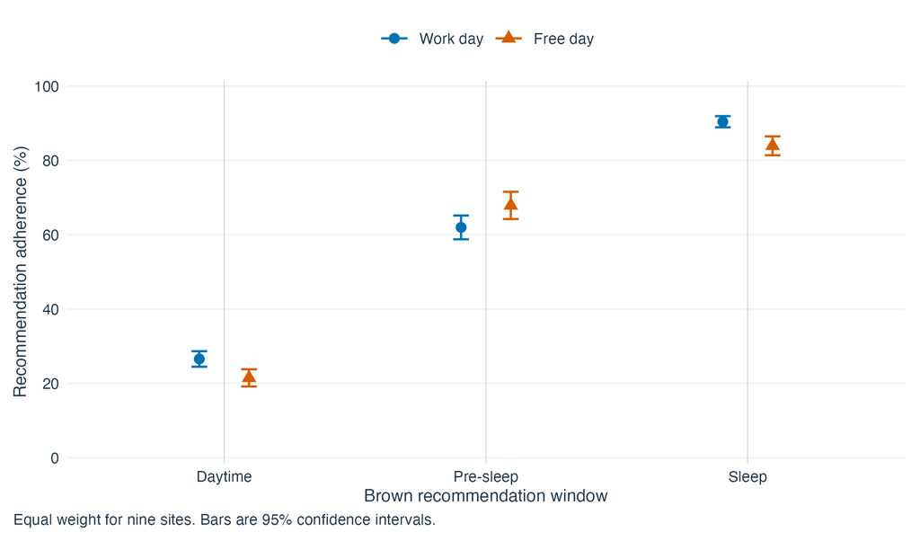

Figure 1: Current equal-site adherence levels. Daytime, Pre-sleep and Sleep identify the Brown recommendation windows.

Paired source

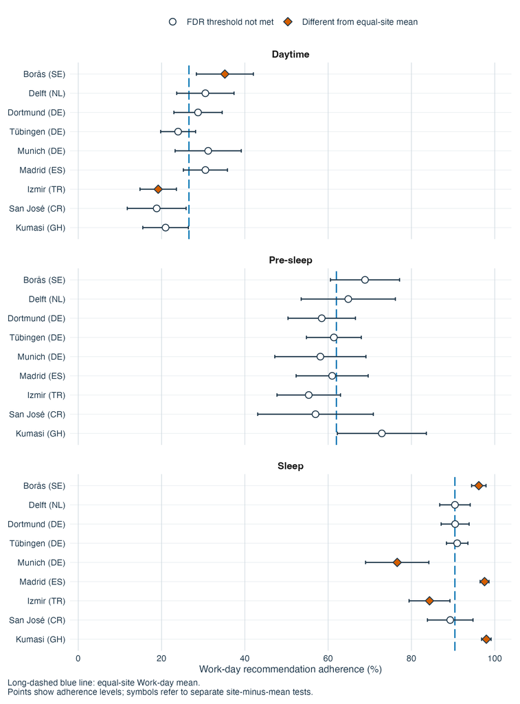

Figure 2: Current Work-day site adherence levels, with distinct site-minus-average tests.

Paired source

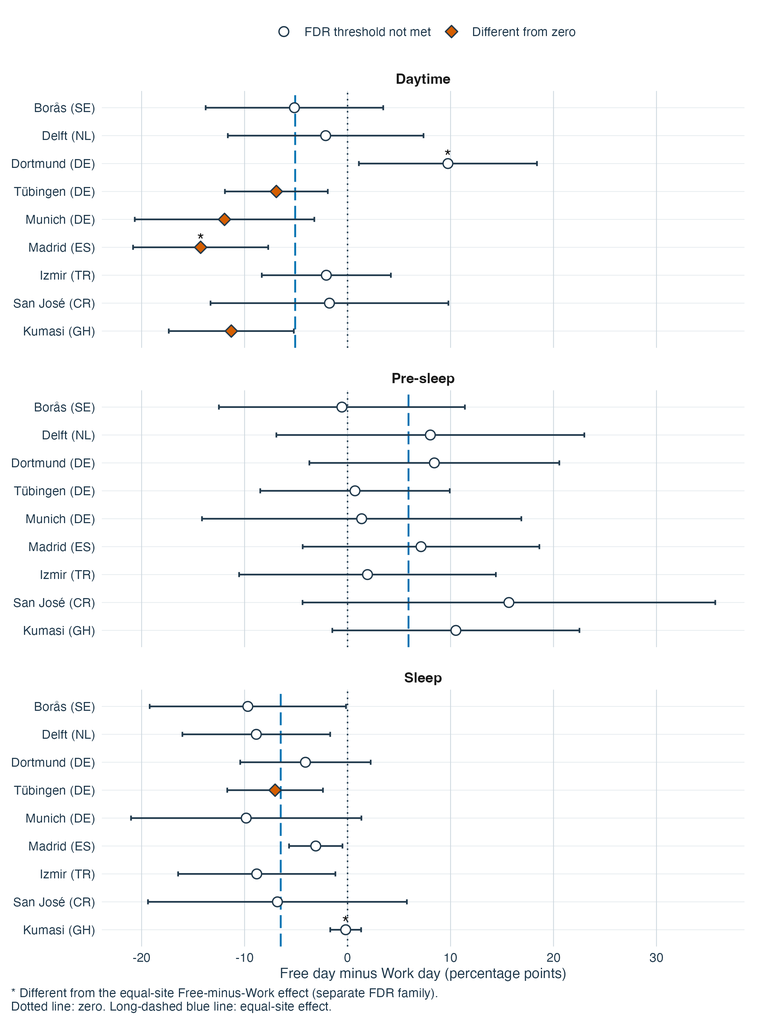

Figure 3: Current site Free-minus-Work differences: diamonds compare with zero; asterisks compare with the equal-site effect.

Paired source

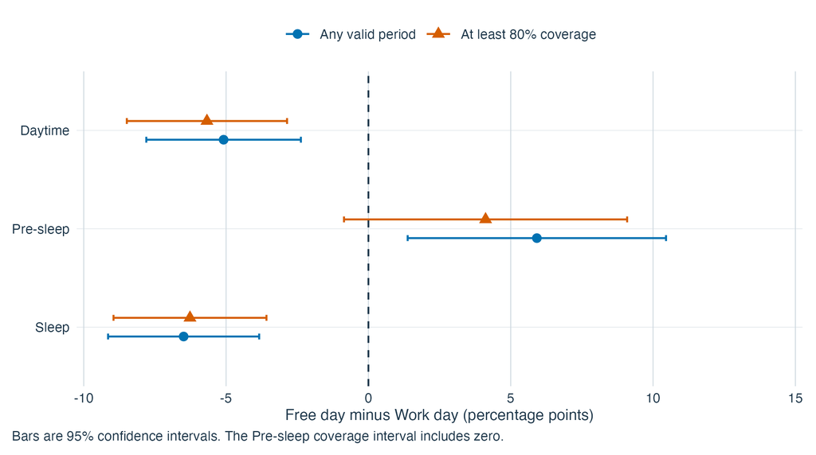

Figure 4: Current coverage comparison. The Pre-sleep 80% interval crosses zero.

Paired source

## 10 Preservation and reproducibility

All 145 complete frozen aggregate exports retain their original identities. Canonical reader preimages are preserved through exact identity-specific historical maps. Older versions continue to use their existing sealed baselines; no old manifest is repinned. The report code never loads restricted participant frames or model RDS files.

Table 27: Frozen output collections and exact identities.

| Role | Path | Bytes | SHA-256 |
| --- | --- | --- | --- |
| Complete current scientific package | main_linkage_b_amendment/stage2/completion_v2/continued_final_package_011/final_manifest.csv | 435249 | c1ce90bf88ff3597d6a75419ee331f091d0a867735117e8785973e1f172af696 |
| Paired aggregate sources | main_linkage_b_amendment/stage2/source_data/manifest.csv | 44221 | 0ae37b58d54650632c92876925e2a2b663e9ff2927a8477b467d0d9c920eb542 |
| Point-only variance decomposition | main_linkage_b_amendment/stage2/r2/manifest.csv | 2462 | 24ebbf2c91ecb0a8d8f0eee659d69d83bcca5114846715fc15c23b09f2bebc98 |
| Exact exploratory reuse | main_linkage_b_amendment/stage2/reuse/manifest.csv | 1179 | 4fc217c3d27daffa05700c11285e7005c6557f1f5bd01cc574a6fe737ece7198 |

Display source

Table 28: Consequential software versions.

| Software | Version |
| --- | --- |
| R | 4.6.1 |
| Quarto | 1.9.37 |
| TMB | 1.9.21 |
| data.table | 1.18.4 |
| gt | 1.3.0 |
| ggplot2 | 4.0.3 |
| knitr | 1.51 |
| digest | 0.6.39 |

Display source

The technical execution and draw accounting remain in `completion_v2/continued_final_package_011/`. Every failed attempt and qualified diagnostic route is preserved. Reporting evidence separately records source-to-claim mapping, candidate promotion, render-attempt history, semantic repair, visual coverage and protected identities.

## 11 Review state

Scientific calculations are complete with the qualifications above. This internal report and the prepared reader sources require independent reporting acceptance. Stage 3 and Stage 4 renders are released separately, serially. Final author acceptance is not presumed and no downstream manuscript or website update is implied.